# Data Visualisation in Python

## 3.2 Multiple Violins

Similarly to the boxplots we can group and then plot the groups in Matplotlib.

```python
# Set up the figure and axis
figure, axes = plt.subplots(figsize=(6, 5))

# remove na values
life_exp = gm_1987[gm_1987["life_exp"].notnull()]

#Plot the visualisation
groups = life_exp.groupby("continent")["life_exp"]

axes.violinplot([groups.get_group("Africa"), # if you encounter any error include- .values after continent name
                 groups.get_group("Americas"),
                 groups.get_group("Asia"),
                 groups.get_group("Europe"),
                 groups.get_group("Oceania")])

# Set Gridlines and colours
```

```python
axes.grid(b = True, axis = "x", c = "white", which = "major")
```

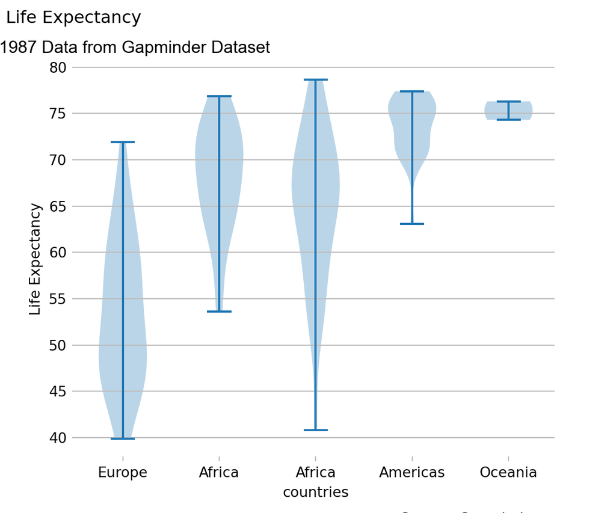

```python
axes.grid(b = True, axis = "y", c = (0.745, 0.745, 0.745), which = "major")
axes.set_frame_on(False)

# Add Labels, Title and Captions
plt.suptitle("Life Expectancy", x = 0.12)
plt.title("1987 Data from Gapminder Dataset" ,
          fontname = "Arial", size = 12, x = 0.12)

figure.text(x=0.65, y=-0.02, s="Source: Gapminder", ha="left")
axes.set_xticklabels(gm_1987["continent"] ) # Adds the continent names in
axes.set_ylabel("Life Expectancy")
axes.set_xlabel("countries")
axes.grid(b = True, which = "major", axis = "y", color = (0.745, 0.745, 0.745))
axes.set_frame_on(False)

# Set Tick Colours to the same grey as our gridlines
axes.xaxis.set_tick_params(color=(0.745,0.745,0.745))
axes.yaxis.set_tick_params(color=(0.745,0.745,0.745))

plt.show();
```

Again in Seaborn we can simply set the hue = parameter to the continent.

```python
# Set up the figure and axes
figure, axes = plt.subplots(figsize=(6,6))

# Plot
violin_plot = sns.violinplot(x = "continent",
                             y = "life_exp",
                             hue = "continent",
                             data = gm_1987)

# Removes the "spines" or edges of our vis
sns.despine(left=True, bottom=True)

# Add Labels, Title and Captions (this comes from Matplotlib!)
plt.suptitle("Life Expectancy", x = 0.22, y = 1., fontname="Arial", size=16,)
plt.title("1987 Data from Gapminder Dataset" ,
          fontname = "Arial", size = 12, x = 0.23, y = 1.05)

plt.text(x=3, y= 20, s="Source: Gapminder", ha="left")
violin_plot.set_ylabel("Life Expectancy (years)")
violin_plot.set_xlabel("Continent")

# Set Gridlines and colours
violin_plot.grid(b = True , which = "both", axis = "y", color = (0.745, 0.745, 0.745))

# Set Tick Colours to the same grey as our gridlines
```

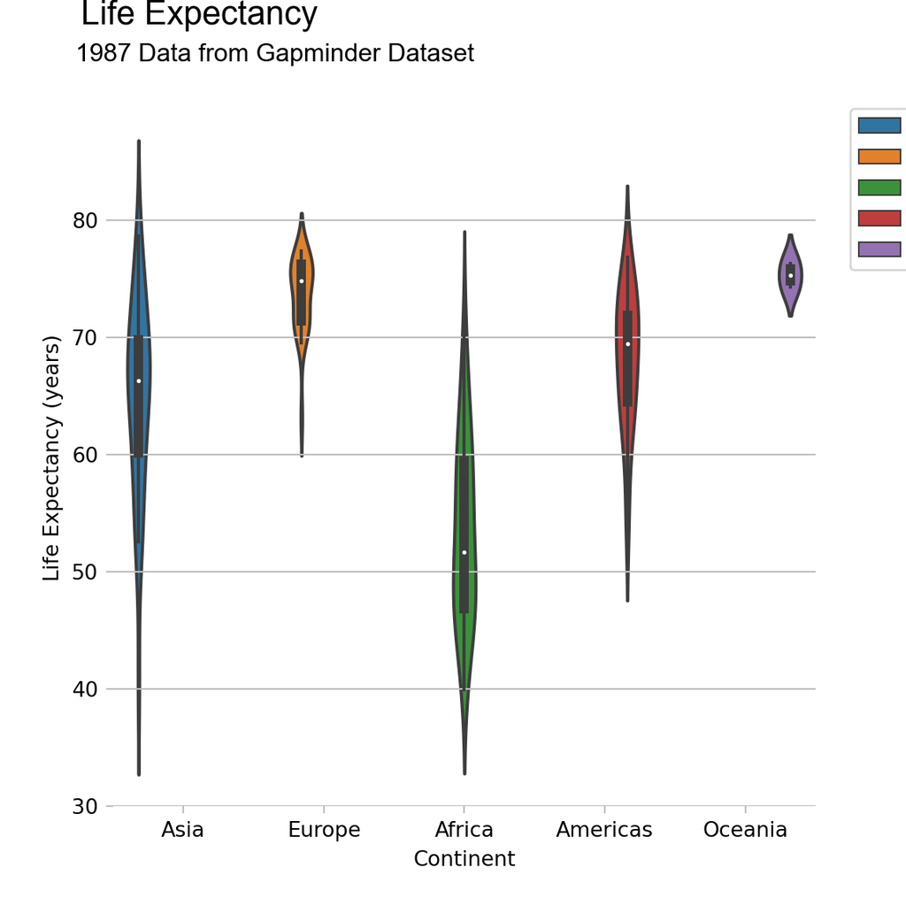

```python
violin_plot.xaxis.set_tick_params(color=(0.745,0.745,0.745))
violin_plot.yaxis.set_tick_params(color=(0.745,0.745,0.745))

plt.legend(bbox_to_anchor=(1.05, 1), loc=2, borderaxespad=0.) # Moves the legend to a box outside of the plot.

plt.show();
```

## 3.3 Horizontal Violin Plots

In Seaborn you can plot a horizontal violin plot, by changing the x and y axis, if desired

```python
# Set up the figure and axes
figure, axes = plt.subplots(figsize=(6,6))

# Plot
```

```python
violin_plot = sns.violinplot(y = "continent",
                             x = "life_exp",
                             hue = "continent",
                             data = gm_1987);

# Removes the "spines" or edges of our vis
sns.despine(left=True, bottom=True)

# Add Labels, Title and Captions (this comes from Matplotlib!)
plt.suptitle("Life Expectancy", x = 0.22, y = 1., fontname="Arial", size=16,)
plt.title("1987 Data from Gapminder Dataset" ,
          fontname = "Arial", size = 12, x = 0.23, y = 1.05)

plt.text(x=70, y=5.3, s="Source: Gapminder", ha="left")
violin_plot.set_xlabel("Life Expectancy (years)")
violin_plot.set_ylabel("Continent")

# Set Gridlines and colours
violin_plot.grid(b = True , which = "both", axis = "y", color = (0.745, 0.745, 0.745))

# Set Tick Colours to the same grey as our gridlines
```

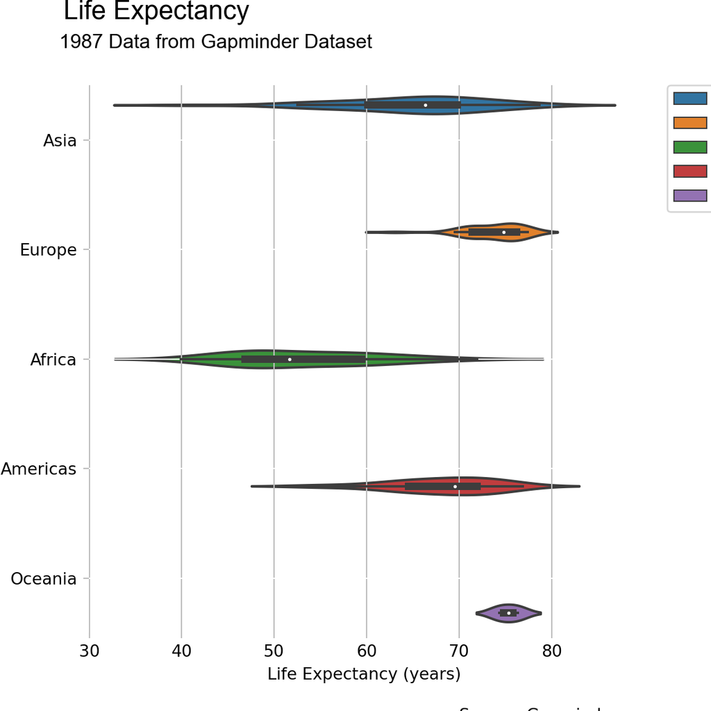

```python
violin_plot.xaxis.set_tick_params(color=(0.745,0.745,0.745))
violin_plot.yaxis.set_tick_params(color=(0.745,0.745,0.745))

axes.grid(b = True , which = "both", axis = "y", color = "white")
axes.grid(b = True , which = "both", axis = "x", color = (0.745, 0.745, 0.745))

plt.legend(bbox_to_anchor=(1.05, 1), loc=2, borderaxespad=0.) # Moves the legend to a box outside of the plot.

plt.show();
```

# 4 End of Chapter

You have completed chapter 5 of the Data Visualisation course. Please move on to chapter 6.